# The Effect of Air Quality on Respiratory Illnesses

Math 268: Data Analysis and Visualization

Joseph Linneman, Theo Mandelbaum, Rose Villareale

Due 11/7/2025

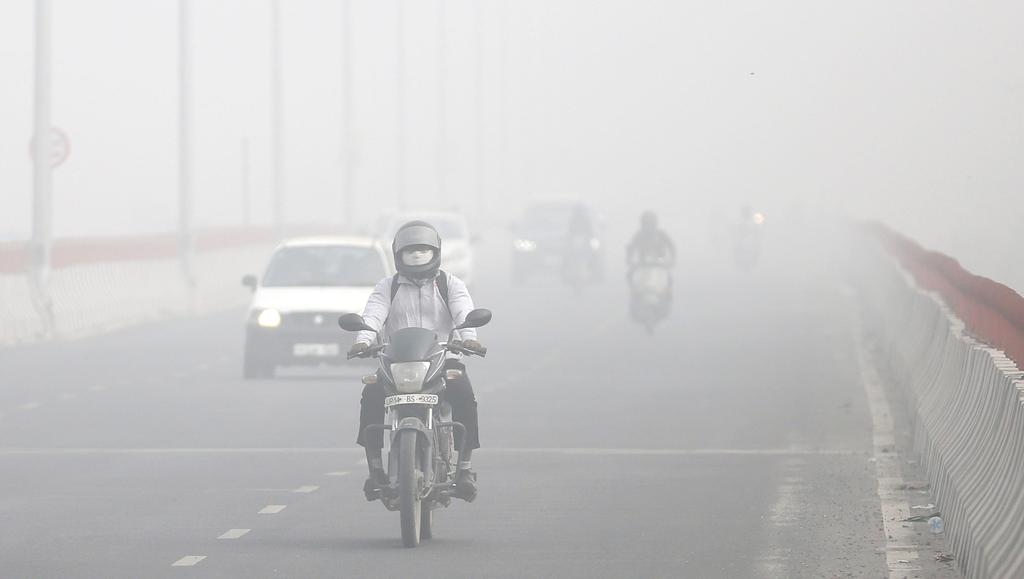

An air-polluted highway in India

## Topics: Air quality, Pollution, Human Illness

This project aims to investigate the relationship between pollution and chronic illnesses in the United States. We chose to focus on air quality rates to measure air pollution. We also chose to focus on respiratory illnesses and cancers, since they are most likely to be affected by air quality compared to other forms of chronic illnesses. We chose to research this topic since pollution is a very prominent problem that the United States is facing, manifesting in ways like increasing temperatures and deadly ailments.

## Project Research Question

What is the strength of the relationship between state-level ozone pollution and AQI levels with chronic respiratory illness rates?

#### Important Definitions

- **Urban**: In close proximity to a city
- **AQI**: Air Quality Index: A tool to report on air pollution levels, communicating potential health risks with a single number. The higher the AQI, the worse the air quality.

## Followup Questions

- Does living closer to cities have an effect on the risk of chronic respiratory illness?
- Does living in areas with higher populations, have an effect on the risk of chronic respiratory illness?
- What are some of the most dangerous counties to live in based on rates of chronic respiratory illness?
- How has air quality changed over time and how has this affected chronic illness rates?
- Do the levels of ozone in the atmosphere correlate with rates of chronic respiratory illnesses?

## Data and Data Source

### Data on Chronic Disease Infection

[Link to Dataset](https://catalog.data.gov/dataset/u-s-chronic-disease-indicators)

#### Here is a snippet of our data, specifically the way that the values are measured.

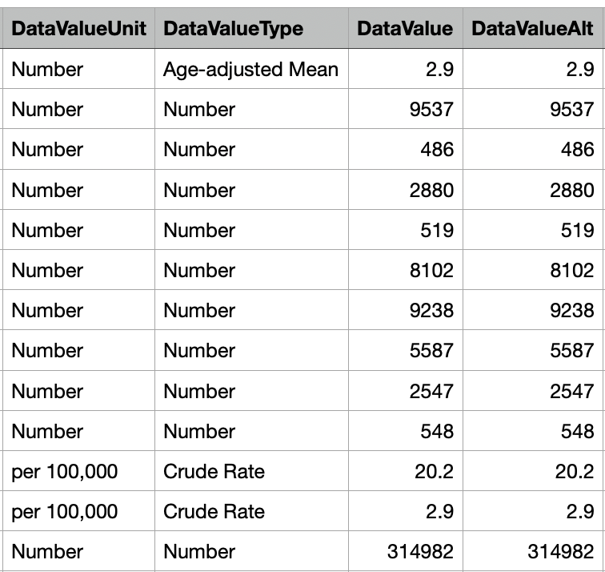

#### Next is a snippet of the metrics the we plan to use to sort our data; i.e. the location where the data is recorded. We plan to use the **LocationDesc** field to organize the chronic diseases data, as this field’s structure matches up with the State field of our other data set.

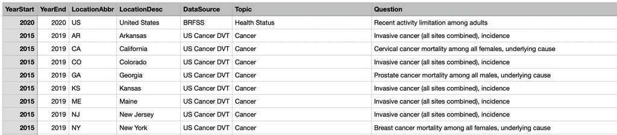

### Chronic Disease Data Validity

The data is collected by Centers for Disease Control and Prevention’s Division of Population Health but then processed and standardized by CDC before publication. The result is a compiled data set that covers the state and national level chronic disease indicators, suitable for public use. If you take a look at the data, you’ll see that many of the fields are scattered with blank values. For this reason, we sort our data based on the values that do exist. Thus, avoiding the occasional blank value.

This CDC data set was developed using a cross-cutting set of 115 indicators developed by consensus among the CDC, the Council of State and Territorial Epidemiologists, and the national Association of Chronic Disease Directors. Given that the data was collected and developed under the supervision of multiple professional organizations, the probability of notable bias is likely low. Overall, this data set is highly reliable in terms of minimizing bias, although some potential for bias in the original data collection still exists, even with large sample sizes.

### Data on National Air Quality Metrics

[Link to Dataset](https://aqs.epa.gov/aqsweb/airdata/download_files.html)

#### Here are some snippets for the air quality metrics.

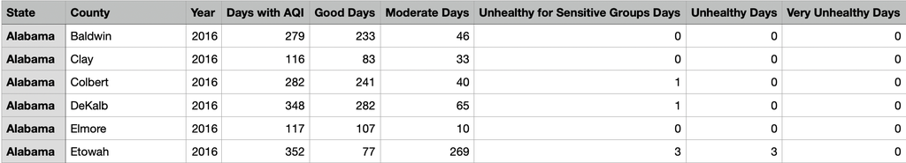

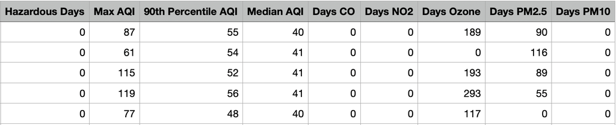

As you can see, each entry has a state, county, and year, allowing us to isolate big cities in the US. In terms of the data collection, we can see how many days were deemed healthy, unhealthy, unhealthy for sensitive groups, hazardous, etc. First, we will sort by state, as that’s the data field that both of the data sets share in common. Once we’ve sorted the air quality data by states, we can compare the AQI measurements and the day totals, to other states.

### Air Quality Data Validity

The air quality data that we’re using comes from the Environmental Protection Agency’s (EPA) Air Quality System (AQS). EPA receives their their data from data collection agencies and incorporates standardized methods, consistent pollutant definitions, and established regulatory criteria. After the data is reported to EPA, EPA calculates several types of federally aggregated data, including the annual air quality data set that we are analyzing. The data that they receive has already been preprocessed, meaning that the data has already been cleaned with. Part of this preprocessing remove any missing values, and fill empty pollution scores with the value 0.

Although the EPA’s AQS dataset follows standardized monitoring protocols and federally defined procedures, there is still some potential for bias in the underlying measurements. There. is room for some variation between local monitoring practices, differences in equipment, and sampling, among the various data collection agencies. Additionally, outliers in pollution data could be produced based on unexpected events, such as wildfires or dust storms. Overall, the EPA’s preprocessing steps work to solve many of the possible bias factors, but bias is still possible.

### Population Data

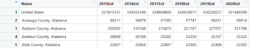

### Population Data Validity

The population data we are using comes from the U.S. Census Bureau’s County Intercensal Estimates for the years 2010–2020. These figures are produced by combining two different data sources: the official decennial census counts and the annual postcensal estimates for each county. The Census Bureau resolves differences between these sources using a standardized methodology, which guarantees that the population totals are consistent across all ten years. Since the intercensal files are generated directly by the Census Bureau and follow well-defined statistical procedures, the dataset is considered highly reliable for analyzing population trends in the United States.

Although the Census Bureau rigorously tries to standardize this data, there is still some room for bias in the population estimates. Some counties may be undercounted or overcounted, despite the verification of birth records, death records, and migration data. This kind of population data can vary from county to county, regardless of the efforts to minimize these inaccuracies. As a result of the nature of population data, there is room for small inaccuracies; however, these inaccuracies should not significantly impact the data analysis that we plan to perform.

#### Next Steps

Once we’ve sorted both data sets as described above, we can answer the question; How strongly does air quality / pollution contribute to risk of chronic respiratory illness?

### Given these datasets, we need to filter the chronic diseases data to figure out which diseases can be labelled as respiratory

#### First, we’ll look at all of the possible options for the Topic columns:

```r
unique_topics <- unique(chronic_diseases$Topic)
print(unique_topics)
```

```
##  [1] "Health Status"
##  [2] "Cancer"
##  [3] "Diabetes"
##  [4] "Sleep"
##  [5] "Immunization"
##  [6] "Nutrition, Physical Activity, and Weight Status"
##  [7] "Oral Health"
##  [8] "Arthritis"
##  [9] "Asthma"
## [10] "Cardiovascular Disease"
## [11] "Disability"
## [12] "Mental Health"
## [13] "Tobacco"
## [14] "Alcohol"
## [15] "Chronic Obstructive Pulmonary Disease"
## [16] "Social Determinants of Health"
## [17] "Cognitive Health and Caregiving"
## [18] "Chronic Kidney Disease"
## [19] "Maternal Health"
```

#### Based on the given topics, here’s a list of which topics can be categorized as respiratory:

#####Definitely respiratory:

- “Asthma”
- “Chronic Obstructive Pulmonary Disease”

##### Could be / need more investigation:

- “Cancer”
- “Tobacco”
- “Sleep”
- “Nutrition, Physical Activity, and Weight Status”

##### Definitely not respiratory:

- “Mental Health”
- “Diabetes”
- “Immunization”
- “Oral Health”
- “Arthritis”
- “Cardiovascular Disease”
- “Disability”
- “Alcohol”
- “Cognitive Health and Caregiving”
- “Maternal Health”
- “Chronic Kidney Disease”
- “Health Status”
- “Social Determinants of Health”

If you look at the list of topics above, some of them are very broad, so to isolate the respiratory diseases, we will need to view all of the possible options for the Question column, within certain topics. After we’ve investigated our options the Question column, we can sort our disease data to only include respiratory diseases.

Only lung and bronchial cancer would be respiratory

```r
chronic_diseases %>%
  filter(Topic == "Cancer") %>%
  pull(Question) %>%
  unique()
```

```
##  [1] "Invasive cancer (all sites combined), incidence"
##  [2] "Cervical cancer mortality among all females, underlying cause"
##  [3] "Prostate cancer mortality among all males, underlying cause"
##  [4] "Breast cancer mortality among all females, underlying cause"
##  [5] "Invasive cancer (all sites combined) mortality among all people, underlying cause"
##  [6] "Lung and bronchial cancer mortality among all people, underlying cause"
##  [7] "Colon and rectum (colorectal) cancer mortality among all people, underlying cause"
##  [8] "Mammography use among women aged 50-74 years"
##  [9] "Cervical cancer screening among women aged 21-65 years"
## [10] "Colorectal cancer screening among adults aged 45-75 years"
```

Rows 1, 2, 4, and 6 are all respiratory issues

```r
chronic_diseases %>%
  filter(Topic == "Tobacco") %>%
  pull(Question) %>%
  unique()
```

```
## [1] "Quit attempts in the past year among adult current smokers"
## [2] "Current cigarette smoking among adults"
## [3] "Current smokeless tobacco use among high school students"
## [4] "Cigarette smoking during pregnancy among women with a recent live birth"
## [5] "Current tobacco use of any tobacco product among high school students"
## [6] "Current electronic vapor product use among high school students"
## [7] "Proportion of the population protected by a comprehensive smoke-free policy prohibiting smoking in all indoor areas of workplaces and public places, including restaurants and bars"
```

None of the sleep questions fit a respiratory disease

```r
chronic_diseases %>%
  filter(Topic == "Sleep") %>%
  pull(Question) %>%
  unique()
```

```
## [1] "Short sleep duration among children aged 4 months to 14 years"
## [2] "Short sleep duration among high school students"
## [3] "Short sleep duration among adults"
```

Here, row 1, 5 and 10 are all respiratory diseases

```r
chronic_diseases %>%
  filter(Topic == "Nutrition, Physical Activity, and Weight Status") %>%
  pull(Question) %>%
  unique()
```

```
##  [1] "Children and adolescents aged 6-13 years meeting aerobic physical activity guideline"
##  [2] "Obesity among adults"
##  [3] "No leisure-time physical activity among adults"
##  [4] "Consumed vegetables less than one time daily among adults"
##  [5] "Met aerobic physical activity guideline among high school students"
##  [6] "Consumed fruit less than one time daily among adults"
##  [7] "Consumed vegetables less than one time daily among high school students"
##  [8] "Obesity among high school students"
##  [9] "Consumed regular soda at least one time daily among high school students"
## [10] "Met aerobic physical activity guideline for substantial health benefits, adults"
## [11] "Consumed fruit less than one time daily among high school students"
## [12] "Infants who were breastfed at 12 months"
## [13] "Infants who were exclusively breastfed through 6 months"
## [14] "Obesity among WIC children aged 2 to 4 years"
```

##### Now, we’re ready to filter our data.

```r
respiratory_diseases <- chronic_diseases %>%
  filter(
    Topic %in% c("Asthma", "Cancer", "Tobacco", "Nutrition, Physical Activity, and Weight Status") &
    (
      (Topic == "Cancer" & Question == "Lung and bronchial cancer mortality among all people, underlying cause") |
      (Topic == "Tobacco" & Question %in% c(
        "Quit attempts in the past year among adult current smokers",
        "Current cigarette smoking among adults",
        "Cigarette smoking during pregnancy among women with a recent live birth",
        "Current electronic vapor product use among high school students"
      )) |
      (Topic == "Nutrition, Physical Activity, and Weight Status" & Question %in% c(
        "Children and adolescents aged 6-13 years meeting aerobic physical activity guideline",
        "Met aerobic physical activity guideline among high school students",
        "Met aerobic physical activity guideline for substantial health benefits, adults"
      )) |
      (Topic == "Asthma") |
      (Topic == "Chronic Obstructive Pulmonary Disease")
    )
  )
```

## Graphed Results

```r
 population_data_cleaned <- population_data %>%
  filter(.[[1]] != "United States") %>%
  select(1, 8:ncol(.)) %>%
  setNames(c("Name", paste0(2015:2020))) %>%
  mutate(
    County = Name %>%
      sub("^\\.", "", .) %>%            # remove leading dot
      sub("\\s*County,.*$", "", .)      # remove ' County, ...'
  )
```

- Population size: Scatter plot with air quality on the y-axis and population on the x-axis

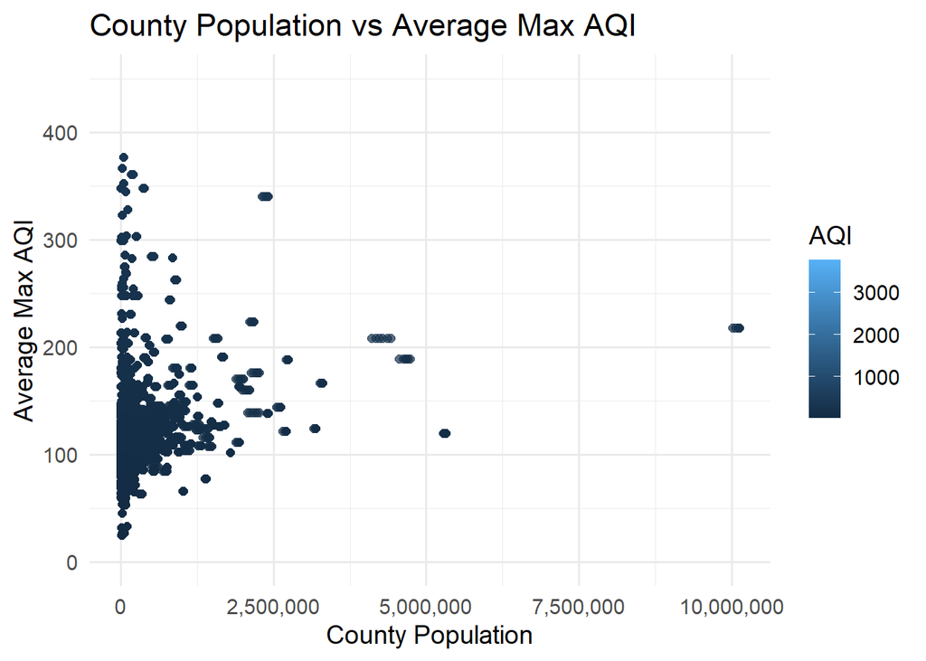

```r
  air_quality_all <- bind_rows(
  air_quality_2015,
  air_quality_2016,
  air_quality_2017,
  air_quality_2018,
  air_quality_2019,
  air_quality_2020
)

# Modify population data for easy joining with AQI
population_long <- population_data_cleaned %>%
  pivot_longer(
    cols = starts_with("20"), # get just the years
    names_to = "Year",
    values_to = "Population"
  ) %>%
    mutate(Year = as.integer(Year))


  # Group Air Quality by State
  aqi_county <- air_quality_all %>%
  group_by(County) %>%
  summarise(AQI = mean(Max.AQI, na.rm = TRUE))

  scatter_data <- population_long %>%
  left_join(aqi_county, by = c("County")) %>%
    filter(!is.na(AQI) & !is.na(Population))


ggplot(scatter_data, aes(x = Population, y = AQI, color = AQI)) +
  geom_point(alpha = 0.7, size = 2) +
  scale_x_continuous(labels = scales::comma) +
  scale_y_continuous(
    limits = c(0, 450),  # clip y-axis to a reasonable max
  ) +
  labs(
    title = "County Population vs Average Max AQI",
    x = "County Population",
    y = "Average Max AQI",
    color = "AQI"
  ) +
  theme_minimal(base_size = 14)
```

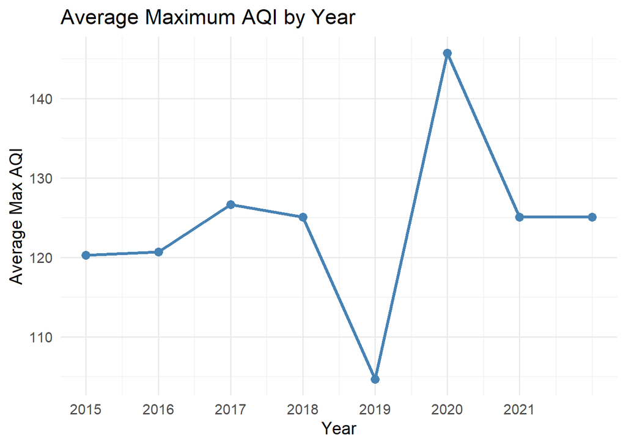

```r
# Combine all air quality datasets into one long table
aqi_long <- bind_rows(
  air_quality_2015 %>% mutate(Year = 2015),
  air_quality_2016 %>% mutate(Year = 2016),
  air_quality_2017 %>% mutate(Year = 2017),
  air_quality_2018 %>% mutate(Year = 2018),
  air_quality_2019 %>% mutate(Year = 2019),
  air_quality_2020 %>% mutate(Year = 2020),
  air_quality_2018 %>% mutate(Year = 2021),
  air_quality_2018 %>% mutate(Year = 2022)
)

# Average AQI per year
aqi_yearly <- aqi_long %>%
  group_by(Year) %>%
  summarise(Avg_AQI = mean(Max.AQI, na.rm = TRUE))


ggplot(aqi_yearly, aes(x = Year, y = Avg_AQI)) +
  geom_line(size = 1.2, color = "steelblue") +
  geom_point(size = 3, color = "steelblue") +
  scale_x_continuous(breaks = 2015:2021) +
  labs(
    title = "Average Maximum AQI by Year",
    x = "Year",
    y = "Average Max AQI"
  ) +
  theme_minimal(base_size = 14)
```

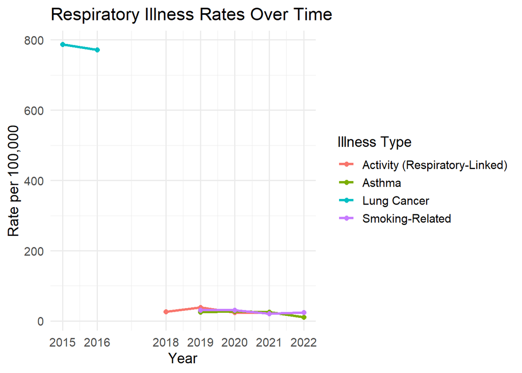

```r
# Build a dataset of illness rates by year and illness type
illness_long <- respiratory_diseases %>%
  filter(!is.na(DataValue)) %>%
  mutate(
    Illness = case_when(
      Topic == "Asthma" ~ "Asthma",
      Topic == "Chronic Obstructive Pulmonary Disease" ~ "COPD",
      Topic == "Cancer" ~ "Lung Cancer",
      Topic == "Tobacco" ~ "Smoking-Related",
      Topic == "Nutrition, Physical Activity, and Weight Status" ~ "Activity (Respiratory-Linked)",
      TRUE ~ Topic
    ),
    # Use YearStart when available, otherwise YearEnd
    Year = if_else(!is.na(YearStart), YearStart, YearEnd)
  ) %>%
  group_by(Year, Illness) %>%
  summarise(Rate = mean(DataValue, na.rm = TRUE), .groups = "drop")


# Plot
ggplot(illness_long, aes(x = Year, y = Rate, color = Illness)) +
  geom_line(size = 1.2) +
  geom_point(size = 2) +
  scale_x_continuous(breaks = sort(unique(illness_long$Year))) +
  labs(
    title = "Respiratory Illness Rates Over Time",
    x = "Year",
    y = "Rate per 100,000",
    color = "Illness Type"
  ) +
  theme_minimal(base_size = 14)
```